# Giotto Interoperability

Iqra Amin, Irzam Sarfraz

2023-08-02

## Introduction

Giotto suite offers interoperability with other tools for spatial transcriptomics including the ones available from Bioconductor. For this purpose, Giotto provides converter functions that convert Giotto object to SpatialExperiment object and vice versa for use with any of the Bioconductor tools or the Giotto toolkit.

Here we show one such example where we load a Giotto object, convert to a SpatialExperiment object, use packages from Bioconductor to perform some processing on the object and then convert it back to Giotto for use with Giotto toolkit.

## Convert Giotto to SpatialExperiment

We first load an example Visium mouse brain dataset in the form of a mini Giotto object using the GiottoData package:

```r
library(Giotto)
library(GiottoData)

g <- GiottoData::loadGiottoMini(dataset = "visium", python_path ="/share/pkg.7/python3/3.8.3/install/bin/python")
print(g)
```

[output not shown]

Now, we convert the Giotto object into a SpatialExperiment object using the converter function giottoToSpatialExperiment provided with the Giotto suite toolkit:

```r
library(SpatialExperiment)

gspe <- giottoToSpatialExperiment(g)
```

The function returns a list of SpatialExperiment objects, where each element of the list is a single object representing an invdividual unit in the Giotto object. We use the first element for downstream analysis:

```r
spe <- gspe[[1]]
print(spe)
```

```
## class: SpatialExperiment
## dim: 634 624
## metadata(1): image
## assays(3): raw_rna_cell normalized_rna_cell scaled_rna_cell
## rownames(634): Gna12 Ccnd2 ... 9630013A20Rik 2900040C04Rik
## rowData names(7): feat_ID nr_cells ... mean_expr_det hvf
## colnames(624): AAAGGGATGTAGCAAG-1 AAATGGCATGTCTTGT-1 ... TTGTGGCCCTGACAGT-1
##   TTGTTCAGTGTGCTAC-1
## colData names(7): cell_ID nr_feats ... custom_leiden sample_id
## reducedDimNames(5): pca custom_pca umap custom_umap tsne
## mainExpName: NULL
## altExpNames(0):
## spatialCoords names(2) : sdimx sdimy
## imgData names(0):
```

## Identify top spatially variable genes with nnSVG

```r
library(nnSVG)

# One of the assays should be "logcounts"
# We rename the normalized assay to "logcounts"
assayNames(spe)[[2]] <- "logcounts"

# Create model matrix for leiden clustering labels
X <- model.matrix(~ colData(spe)$leiden_clus)
dim(X)
```

```
## [1] 624   2
```

```r
# Run nnSVG
spe <- nnSVG(spe, X = X)

# Show top 10 features
rowData(spe)[order(rowData(spe)$rank)[1:10], ]$feat_ID
```

```
##  [1] "Ttr"    "Ddn"    "Tcf7l2" "Zic1"   "Hpca"   "Prkcd"  "Tnnt1"  "Cplx2"  "Shox2"  "Vxn"
```

## Conversion of SpatialExperiment object back to Giotto

We now convert the processed SpatialExperiment object back to Giotto object to perform further downstream analysis with Giotto suite. We use the function spatialExperimentToGiotto and specify the spatial network from our SpatialExperiment object explicitly.

```r
giottoFromSPE <- spatialExperimentToGiotto(spe = spe, python_path = "/share/pkg.7/python3/3.8.3/install/bin/python", sp_network = "Delaunay_network")
```

```
##
##  external python path provided and will be used
```

```
## Creating Giotto object with raw_rna_cell matrix
```

```
## Copying expression matrix: logcounts
```

```
## Copying expression matrix: scaled_rna_cell
```

```
## Copying phenotype data
```

```
## Copying feature metadata
```

```
## Copying reduced dimensions
## Copying reduced dimensions
## Copying reduced dimensions
## Copying reduced dimensions
## Copying reduced dimensions
```

```
## Copying spatial locations
```

```
## > raw already exists and will be replaced with new spatial locations
```

```
## Copying spatial networks
```

```
## Copying additional networks
## Copying additional networks
## Copying additional networks
```

```r
print(giottoFromSPE)
```

```
## An object of class giotto
## >Active spat_unit:  cell
## >Active feat_type:  rna
## [SUBCELLULAR INFO]
## [AGGREGATE INFO]
## expression -----------------------
##   [cell][rna] raw logcounts scaled_rna_cell
## spatial locations ----------------
##   [cell] raw
## spatial networks -----------------
##   [cell] Delaunay_network
## dim reduction --------------------
##   [cell][rna] pca custom_pca umap custom_umap tsne
## nearest neighbor networks --------
##   [cell][rna] sNN.pca custom_NN spatial_network
##
##
## Use objHistory() to see steps and params used
```

## Plotting top genes from nnSVG in Giotto

Now we visualize the genes identified previously in the SpatialExperiment object using nnSVG package in the Giotto toolkit using the converted Giotto object.

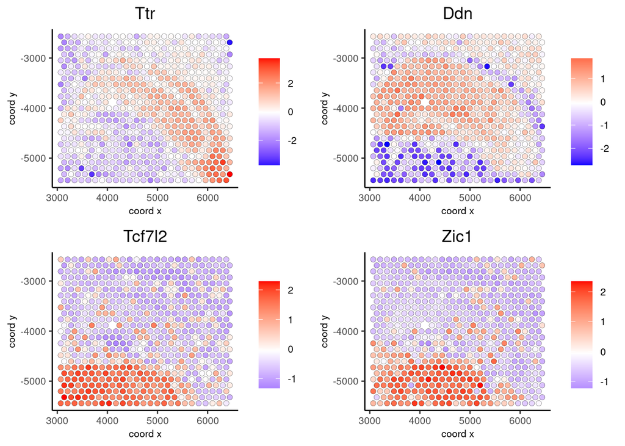

[figure not shown]

```r
ext_spatial_genes <- getFeatureMetadata(giottoFromSPE, output = "data.table")
ext_spatial_genes <- ext_spatial_genes[order(ext_spatial_genes$rank)[1:10], ]$feat_ID

spatFeatPlot2D(giottoFromSPE, expression_values = 'scaled_rna_cell',
               feats = ext_spatial_genes[1:4], point_size = 2)
```